# Project Summary

Jon Page

12/05/2020

# ISSUE - 27/05/2020

Some of the sites had missing ANPP data in the middle of their datasets. The original method of removing these just, well, removed them and the corresponding years. This meant that the data series was no longer consecutive and may have affected the site results. The sites affected are:

- Lahav
- Matta
- Prades
- SGS

e.g. At Lahav, the year 2005 was removed and so 2004 and 2006 became consecutive in the data series.

A new method of removing years missing ANPP data only removes them from the beginning and end of the data series (because ideally we don’t want missing ANPP). It leaves in any missing data in the middle of a time series (note all sites only had 1 year of missing data at most) as SAM can deal with this by inferring a value for the missing year (this does increase the importance of a decent prior). All old outputs for these 4 sites have been archived and new model runs are being conducted.

This workbook has since been updated with the new model work and should now be correct.

## SAM ANPP Model Analysis

This is a R Markdown file to collect my curated thoughts and outputs resulting from this project. I am attempting to explore the ability of various terrestial biosphere models (TBMs) to predict ecosystem productivity and the role that antecedent conditions of climatic drivers play in productivity responses.

More incoherent ramblings are saved in a LaTeX document on Overleaf - this file is a summary of my progress.

### P-ANPP SAM Modelling of Sites

The first step was to model the 10 sites from Paschalis et al (2020) using the SAM approach with precipitation (P) as the only driver. The key result from this is that only one sites indicate a significant response of ANPP to antecedent P, as per the below figure

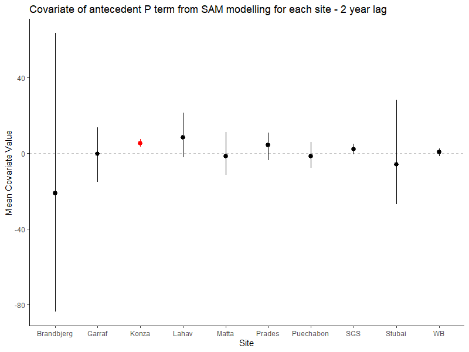

This is Konza. As can be seen from the weights, the current year exerts the most influence, with July/May/March having the highest weighting.

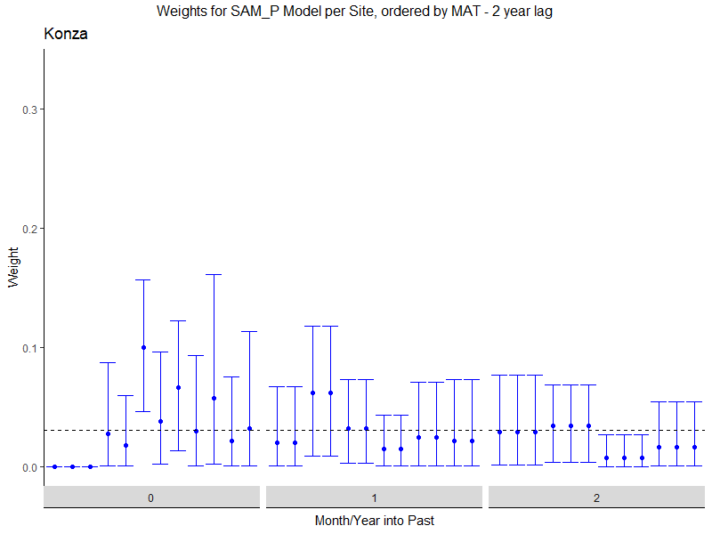

I have run the SAM script for 1, 2, 4 and 5 year lags as well. An interesting result is that the significance of antecedent rainfall depends heavily on the length of lag considered and not in an ideal mannner. For instance $P_{ant}$ is only significant at Brandbjerg for a lag of 2 years. Ideally I believe a method where, if lag 2 is significant, then lag 3,4,5 will be as well because it is possible for the monthly weights to capture this.

1 Year

2 Year

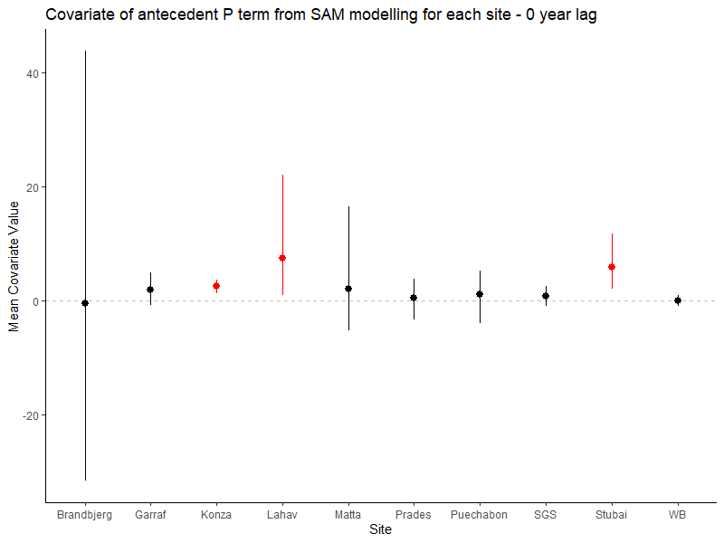

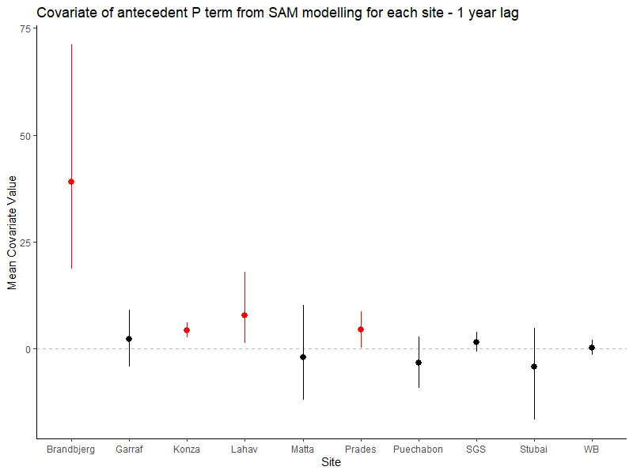

4 Year

5 Year

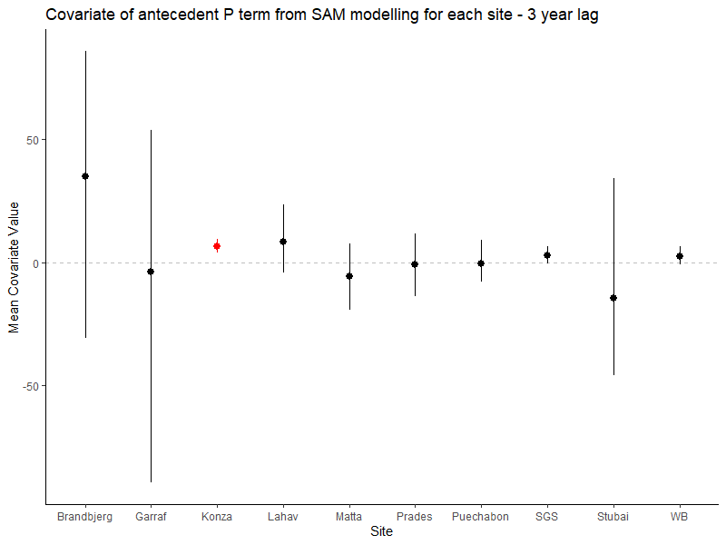

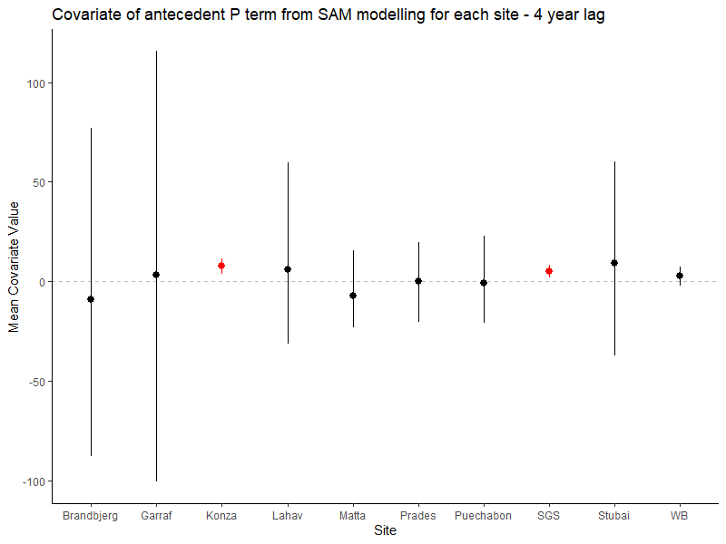

The extreme influence of the choice of Nlag (looking back Nlag-1 years) is disconcerting.

### Added Temperature

I have added temperature to the model - it is in exactly the same form as the antecedent precipitation. This is currently using mean monthly temperature which I believe will “smooth” the input too much and make it difficult to distinguish any dependence.

In the below plots, diamonds (on the left) are the P covariate and circles (on the right) are the T covariate. Red indicates that they are significantly different from 0. The covariates have been normalised by dividing by the mean but the extensive CIs at individual sites mean that the error bars at some sites are still not visible. I am not happy with these plots - they could be much more readable.

1 Year

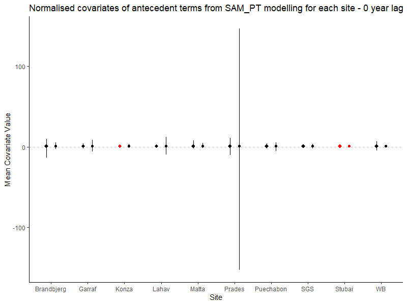

2 Year

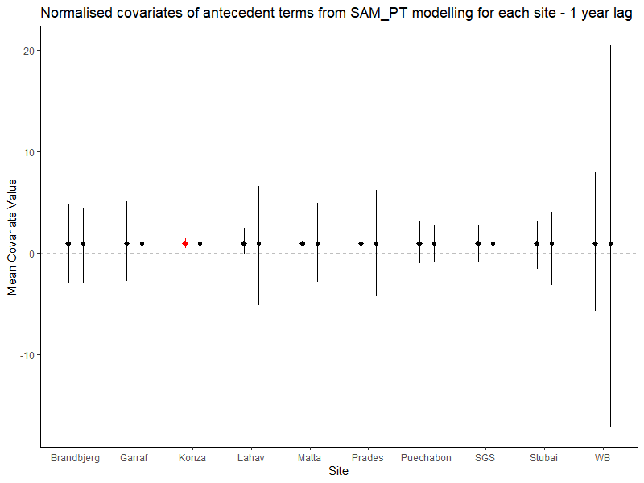

3 Year

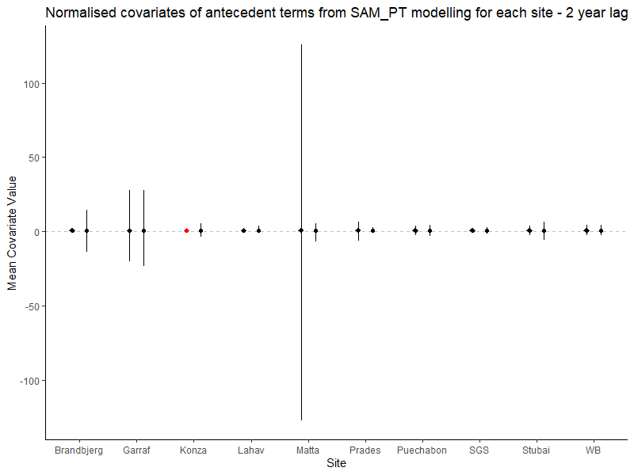

4 Year

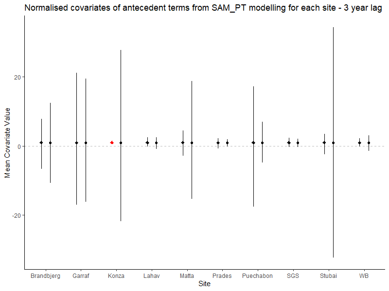

5 Year

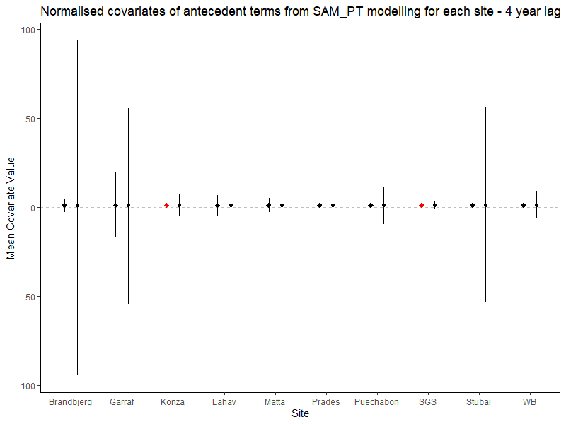

I see the below issues:

- Similarly to the P model, site covariates lose significance when longer lags are explored - see Stubai, Nlag = 1. This is not ideal behaviour in the model.
- Sites report differing significance of the P covariate between the P and PT models. What does this mean in terms of the site’s dependence on antecedent P?

## Model Comparison

The SAM method is applied to all sites using the modelled ANPP data from the 5 models. The results can then be compared to SAM outputs for the observed ANPP. This will hopefully provide insight into the following:

- Whether models capture any lags evident in the data
- Why models might differ in their outputs - do some models have a lag effect where others don’t?

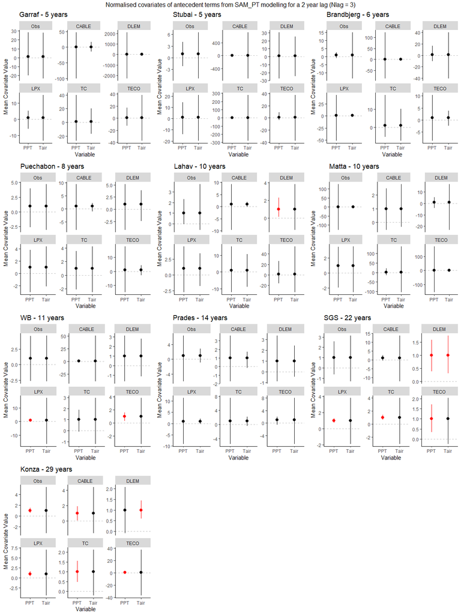

### SGS

We now focus on SGS, in particular the antecedent P term, and look into the differences between the models. SGS is a grassland site with low MAT (8.5C) and low rainfall (300mm). These are both the 2nd lowest of all sites. Coefficient of variation for precipitation is high however at 0.4, the highest of all sites.

The site is likely temperature and water limited. As such, when in the year the precipitation falls is probably quite important.

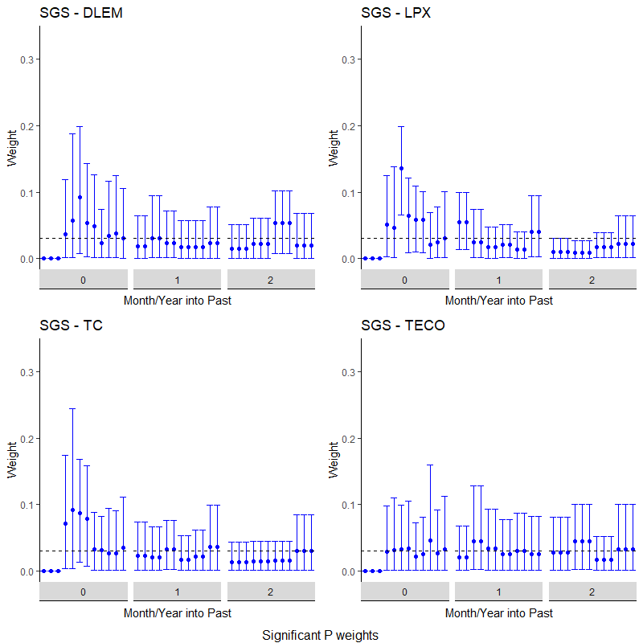

No models show any real long-term seasonal lags with weights in years 1 and 2 being largely uniform. The lags are noticeably more heavily weighted to year 0 in DLEM, LPX and TC. However, observations of ANPP and P at SGS show no correlation. *How accurately do these models capture the behaviour at SGS?*

Another interesting feature is that the cumulative P weights for the models reach 90% (as used by Kiona to define the length of the lag) at 33, 31, 33 and 33 months respectively. The prior for the site reaches 90% at month 33, and so there is no real difference here.

| MODEL | Year 0 Weight | Year -1 Weight | Year -2 Weight | Months to 90% Weight |
| --- | --- | --- | --- | --- |
| DLEM | 0.403 | 0.262 | 0.335 | 33 |
| LPX | 0.484 | 0.342 | 0.174 | 31 |
| TC | 0.472 | 0.303 | 0.225 | 33 |
| TECO | 0.271 | 0.357 | 0.372 | 33 |
| Prior | 0.273 | 0.364 | 0.363 | 33 |

### LAI Checks

Martin suggested that the difference between models might be due to LAI differences.

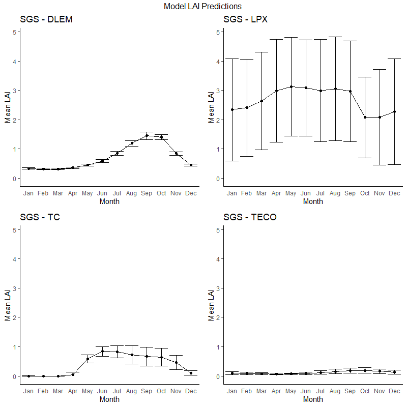

The models however have totally different LAI profiles and highest monthly weights don’t correspond with any obvious peaks in LAI. Martin suggests that looking into GPP might give further insight. The below equation is ANPP but I should remember that allocation to roots is another component of total GPP:

$ANPP = GPP_{leaf} + GPP_{stem} - R_{A}$

We want to determine why each model suggests that ANPP is related to P. It might be worth checking correlation of P to modelled ANPP for these models - do we even need the lags?

## Testing sampled Konza data

I have written a script which runs SAM with Nlag = 3 for every consecutive run of 10 years at Konza. Note the script takes any site, model, or sample length. I used Konza and observations as this is the longest dataset.

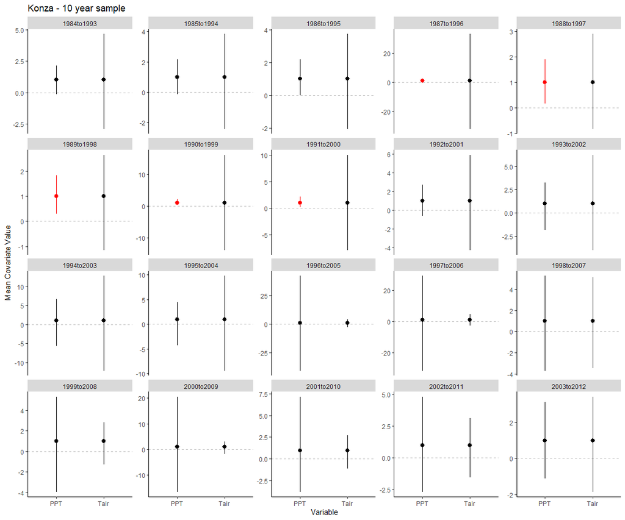

This is very interesting. There is a period of time 1987-2000 which exhibits significance on P while nowhere else does. I need to look at these dates and see if there is anything different compared to the years that don’t produce significance.